# h4

Yating Tian

2/18/2020

1. For each of parts (a) through (d), indicate whether we would generally expect the performance of a flexible statistical learning method to be better or worse than an inflexible method. Justify your answer.
1. The sample size n is extremely large, and the number of predictors p is small.

   **The flexible statistical learning method is better because it will fit the data closer and better when the large sample size.**
2. The number of predictors p is extremely large, and the number of observations n is small.

   ** A flexible statistical learning method is worth because it would overfit when there is the small n**
3. The relationship between the predictors and response is highly non-linear.

   **the flexible statistical learning method is better because it will fit the data closer than inflexible method.
4. The variance of the error terms, i.e. σ2 = Var(), is extremely high.

   ** A flexible statistical learning method is worth because it would fit the noise too, which brings more varience to the prediction. **
2. Explain whether each scenario is a classification or regression problem, and indicate whether we are most interested in inference or prediction. Finally, provide n and p.
1. We collect a set of data on the top 500 firms in the US. For each firm we record profit, number of employees, industry and the CEO salary. We are interested in understanding which factors affect CEO salary.

   **regression; inference; n=500;p= 3, (profit, number of employees, industry)**
2. We are considering launching a new product and wish to know whether it will be a success or a failure. We collect data on 20 similar products that were previously launched. For each product we have recorded whether it was a success or failure, price charged for the product, marketing budget, competition price, and ten other variables.

   **classification;prediction; n=20; p=13,(price charged for the product, marketing budget, competition price, and ten other variables)**
3. We are interest in predicting the % change in the USD/Euro exchange rate in relation to the weekly changes in the world stock markets. Hence we collect weekly data for all of 2012. For each week we record the % change in the USD/Euro, the % change in the US market, the % change in the British market, and the % change in the German market.

   **regression;prediction;n= 52;p= 3,(the % change in the US market, the % change in the British market, and the % change in the German market.)**

This exercise involves the Boston housing data set.

```r
#(a) To begin, load in the Boston data set. The Boston data set is part of the MASS library in R. Now the data set is contained in the object Boston. How many rows are in this data set? How many columns? What do the rows and columns represent?
library(tidyverse)
library(MASS)
library(reshape2)
view(Boston)
nrow(Boston) #This is the number of obervation
```

```
## [1] 506
```

```r
ncol(Boston) #This is the number of measured varables of each overvation
```

```
## [1] 14
```

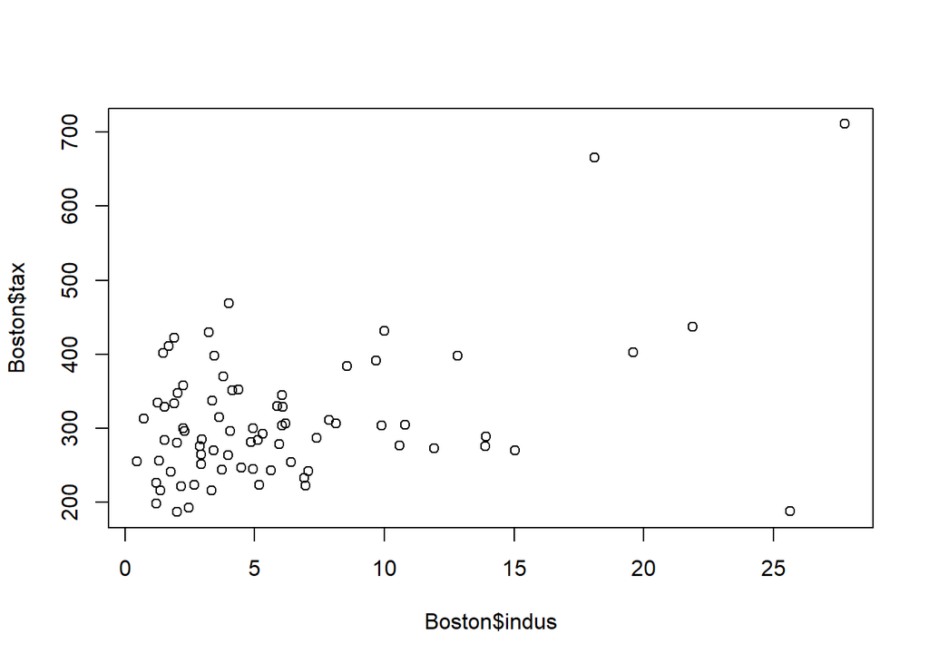

```r
#(b) Make some pairwise scatterplots of the predictors (columns) in this data set. Describe your findings.

plot(Boston$indus, Boston$tax)   #By observing graph, the relationship proportion of non-retail business acres per town and tax has weak positive correlation.
```

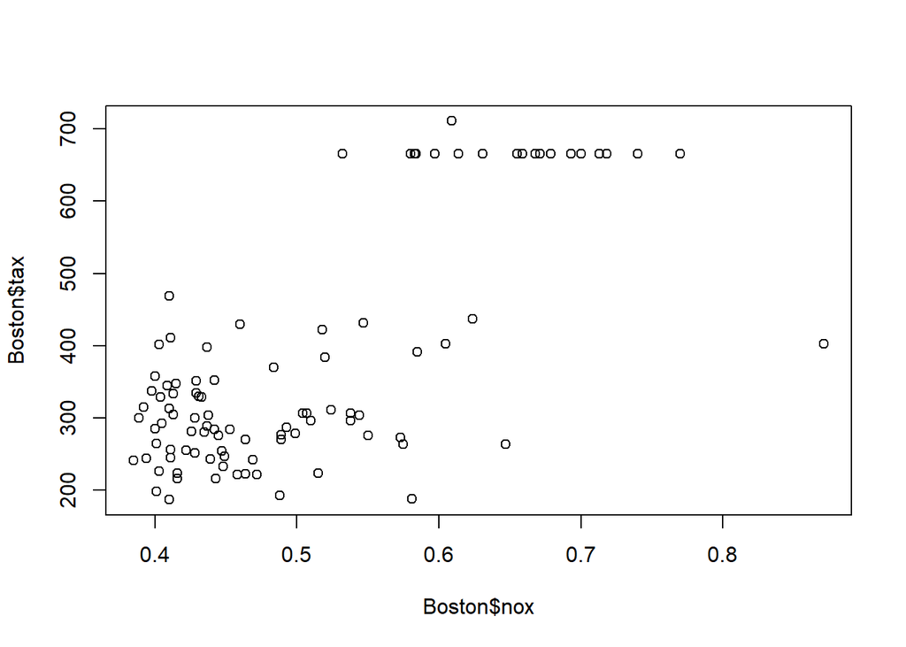

```r
plot(Boston$nox, Boston$tax) #the ralationship between nitrogen oxides concentration and tax is that for more than 0.65 parts per 10 million, more likely to have higher full-value property-tax rate per \$10,000.
```

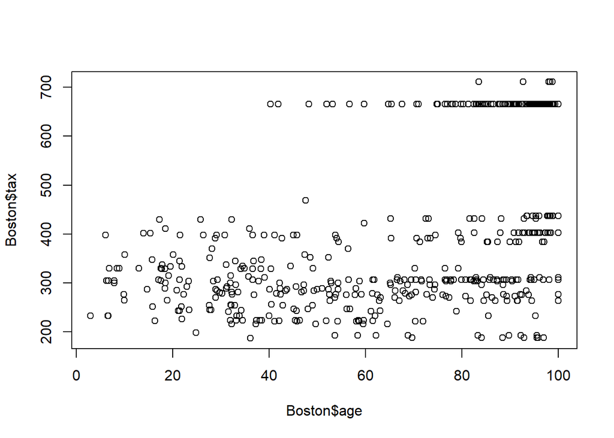

```r
plot(Boston$age, Boston$tax) #people with higher age(after 40) more likely to have highter full-value property-tax rate per \$10,000.
```

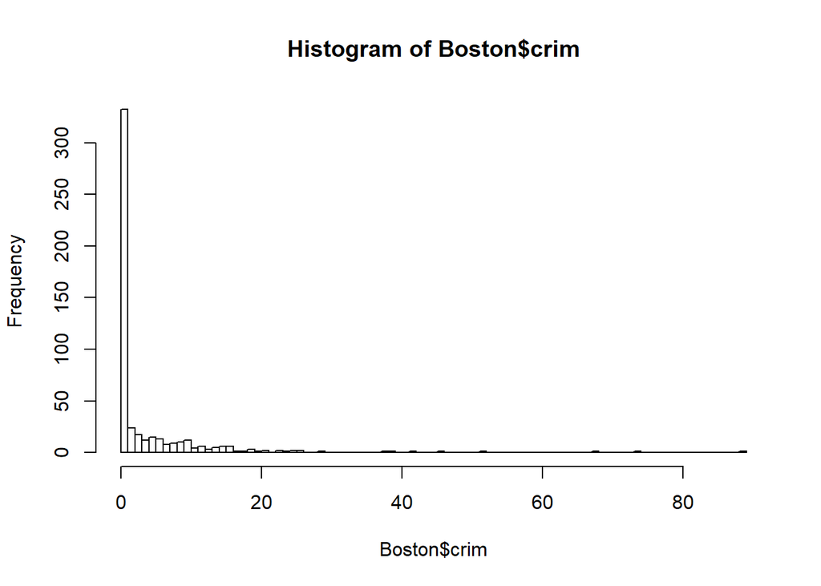

```r
#(c) Are any of the predictors associated with per capita crime rate? If so, explain the relationship.
hist(Boston$crim, breaks = 100) #most of town doesn't have crime or happen 0-1 per capita crime rate. Over 90 % have crime less than 20.
```

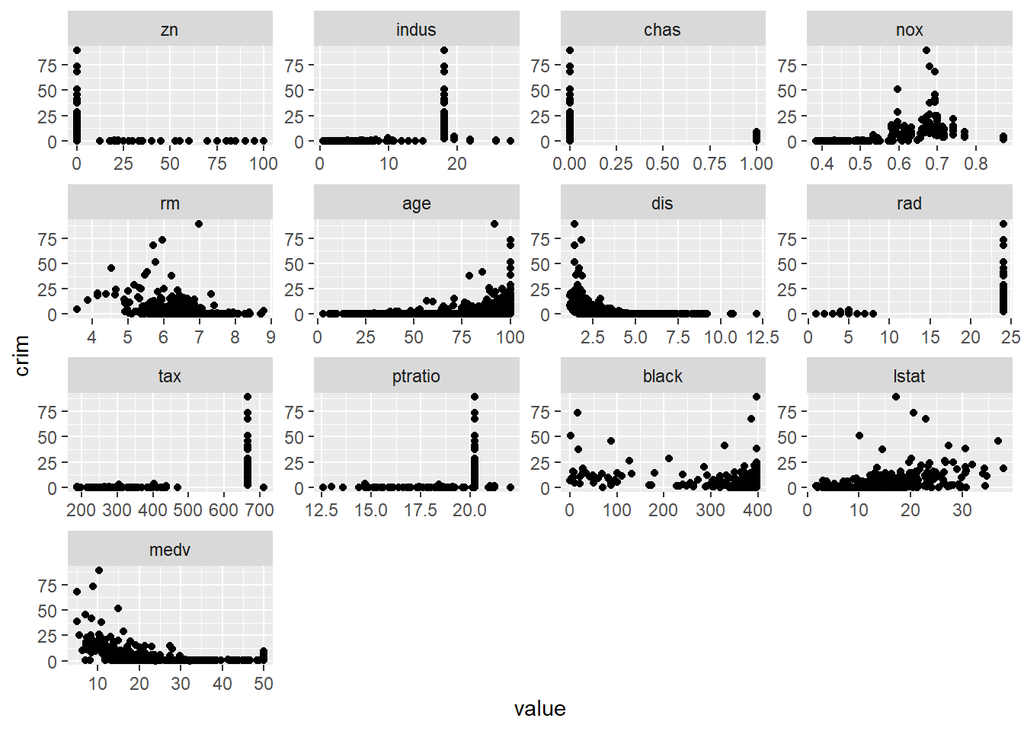

```r
bos <- melt(Boston, id="crim")
ggplot(bos, aes(x=value, y=crim)) +
  facet_wrap(~variable, scales="free") +
  geom_point()
```

```r
#there is no strong liner relationship beween each predictors and crime rate. age/dis/balck/medv might have some non-liner relationship.

#(d) Do any of the suburbs of Boston appear to have particularly high crime rates? Tax rates? Pupil-teacher ratios? Comment on the range of each predictor.
max(Boston$crim)
```

```
## [1] 88.9762
```

```r
Boston[Boston$crim == max(Boston$crim),]
```

```
##        crim zn indus chas   nox    rm  age    dis rad tax ptratio black
## 381 88.9762  0  18.1    0 0.671 6.968 91.9 1.4165  24 666    20.2 396.9
##     lstat medv
## 381 17.21 10.4
```

```r
range(Boston$crim) # 0.00632 88.97620
```

```
## [1]  0.00632 88.97620
```

```r
Boston[Boston$tax == max(Boston$tax),]
```

```
##        crim zn indus chas   nox    rm  age    dis rad tax ptratio  black
## 489 0.15086  0 27.74    0 0.609 5.454 92.7 1.8209   4 711    20.1 395.09
## 490 0.18337  0 27.74    0 0.609 5.414 98.3 1.7554   4 711    20.1 344.05
## 491 0.20746  0 27.74    0 0.609 5.093 98.0 1.8226   4 711    20.1 318.43
## 492 0.10574  0 27.74    0 0.609 5.983 98.8 1.8681   4 711    20.1 390.11
## 493 0.11132  0 27.74    0 0.609 5.983 83.5 2.1099   4 711    20.1 396.90
##     lstat medv
## 489 18.06 15.2
## 490 23.97  7.0
## 491 29.68  8.1
## 492 18.07 13.6
## 493 13.35 20.1
```

```r
range(Boston$tax) #187 711
```

```
## [1] 187 711
```

```r
max(Boston$ptratio)
```

```
## [1] 22
```

```r
Boston[Boston$ptratio == max(Boston$ptratio),]
```

```
##        crim zn indus chas   nox    rm  age     dis rad tax ptratio  black
## 355 0.04301 80  1.91    0 0.413 5.663 21.9 10.5857   4 334      22 382.80
## 356 0.10659 80  1.91    0 0.413 5.936 19.5 10.5857   4 334      22 376.04
##     lstat medv
## 355  8.05 18.2
## 356  5.57 20.6
```

```r
range(Boston$ptratio)  #12.6 22.0
```

```
## [1] 12.6 22.0
```

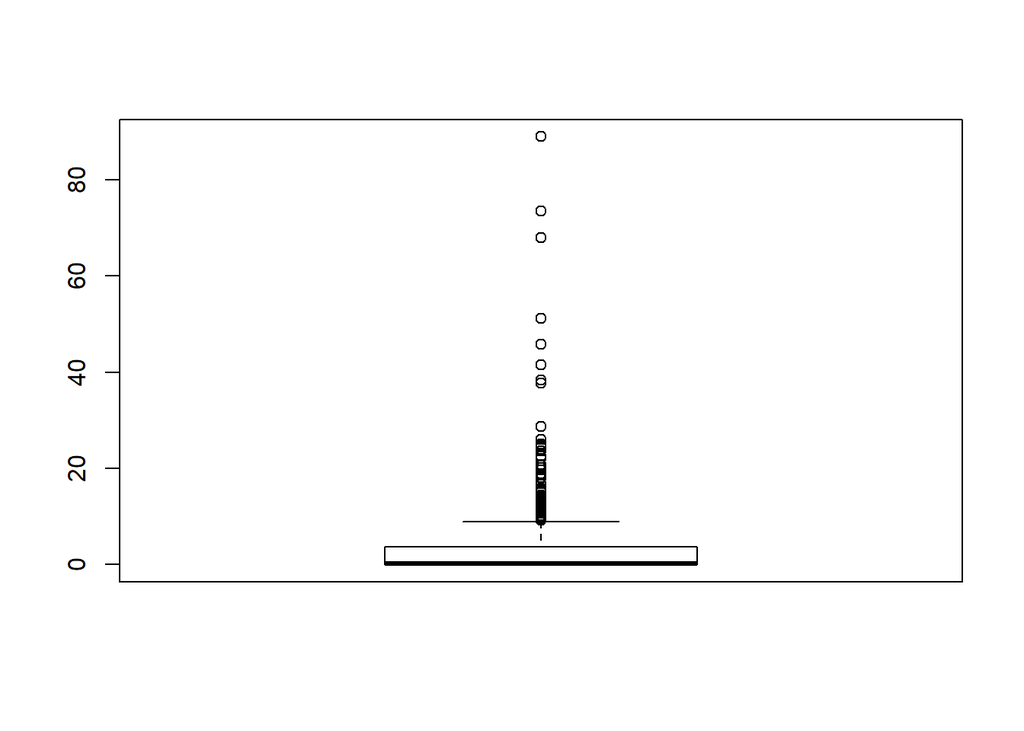

```r
boxplot(Boston$crim)
```